# Sub-challenge 3

Herdiantri Sufriyana

2024-06-10

# Programming environment

# Download raw data

## This study training data

Table S1. Raw data list

| name | size | modified_date | id |
| --- | --- | --- | --- |
| Preprocess.R | 2.6000e+03 | 06/02/2024 10:43 PM | syn60236613 |
| Sample_annotation.csv | 8.9500e+04 | 05/30/2024 8:37 AM | syn60157686 |
| Probe_array.csv | 7.3000e+07 | 05/30/2024 9:04 AM | syn60157718 |
| Probe_annotation.csv | 5.6870e+08 | 05/30/2024 8:49 AM | syn60157694 |
| DetectionP_subchallenge1.csv | 2.7340e+09 | 05/24/2024 5:35 AM | syn59870646 |
| DetectionP_subchallenge2.csv | 4.9870e+09 | 05/24/2024 5:51 AM | syn59872208 |
| Beta_raw_subchallenge1.csv.gz | 5.8690e+09 | 05/24/2024 5:19 AM | syn59868755 |
| Beta_raw_subchallenge2.csv.gz | 1.1008e+10 | 05/24/2024 2:19 PM | syn59898399 |

## Download original series for understanding the data generation process

# Load raw data

## Probe filtering and normalization

Table S3. This study training data list

| GEO Number | N |
| --- | --- |
| GSE228149 | 5 |
| GSE200659 | 11 |
| E_MTAB_9312 | 13 |
| GSE115508 | 25 |
| GSE204977 | 55 |
| GSE169598 | 64 |
| GSE232778 | 187 |
| GSE144129 | 210 |
| GSE167885 | 242 |

# Phenotype preprocessing

## Phenotype preprocessing for conditions

## Phenotype imputation for conditions

### FGR imputation

### PE imputation

### PE onset imputation

### HELLP imputation

### Diandric triploid imputation

### Miscarriage imputation

### Preterm imputation

### GDM imputation

### SGA imputation

### LGA imputation

### SLGA imputation

### IVF imputation

### Subfertility imputation

### Chorioamnionitis imputation

### Apply imputation

## Phenotype preprocessing for non-conditions

# Predictive modeling

## Phenotype correlation matrix among conditions and gestational age

Table S7. Categorical variables with pair-wise perfect separation.

| V1 | V2 |
| --- | --- |
| lga | chorioamnionitis |
| ms_lga | lga |
| preterm | lga |

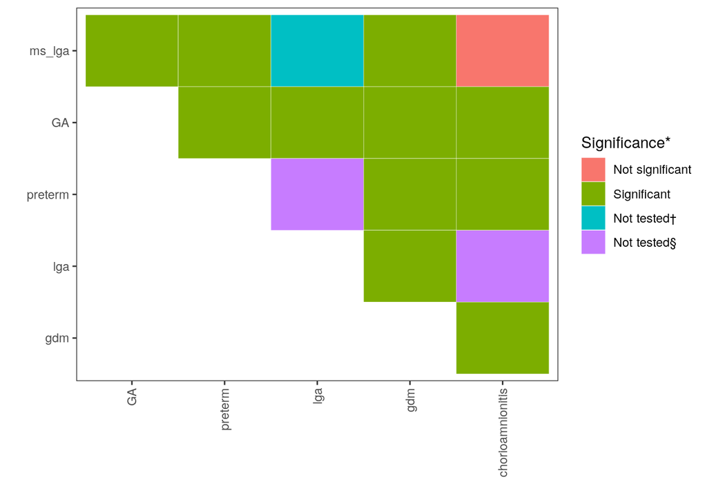

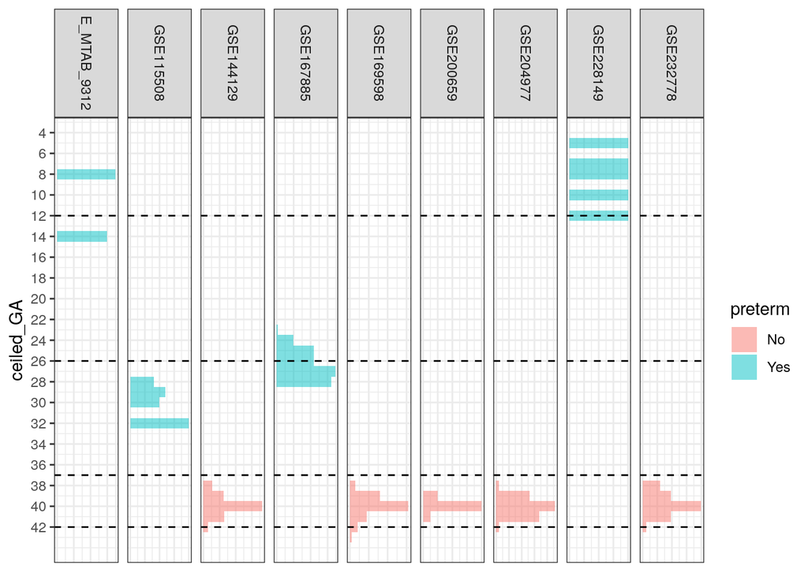

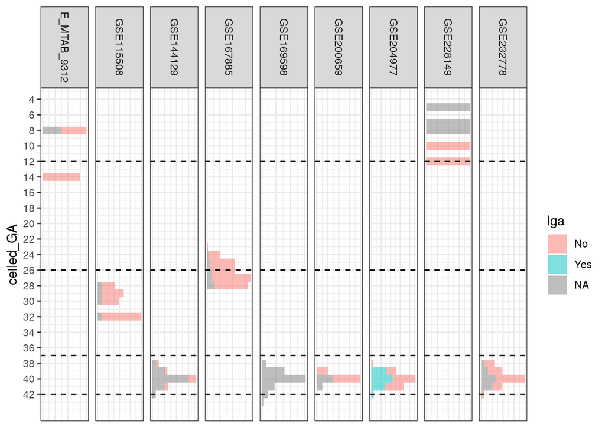

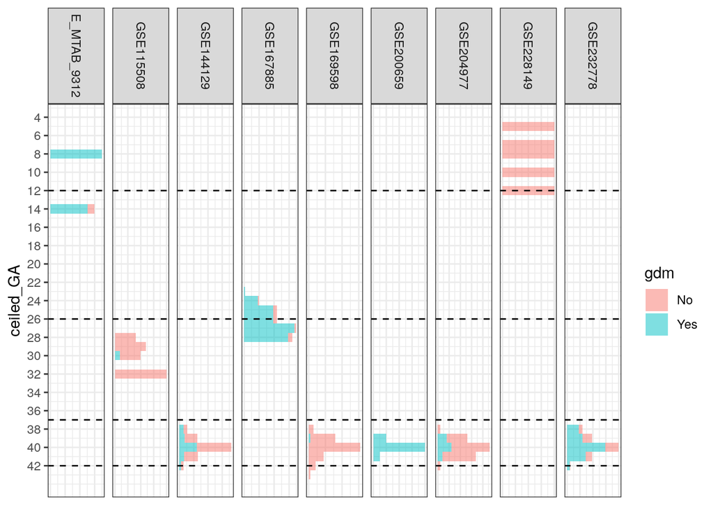

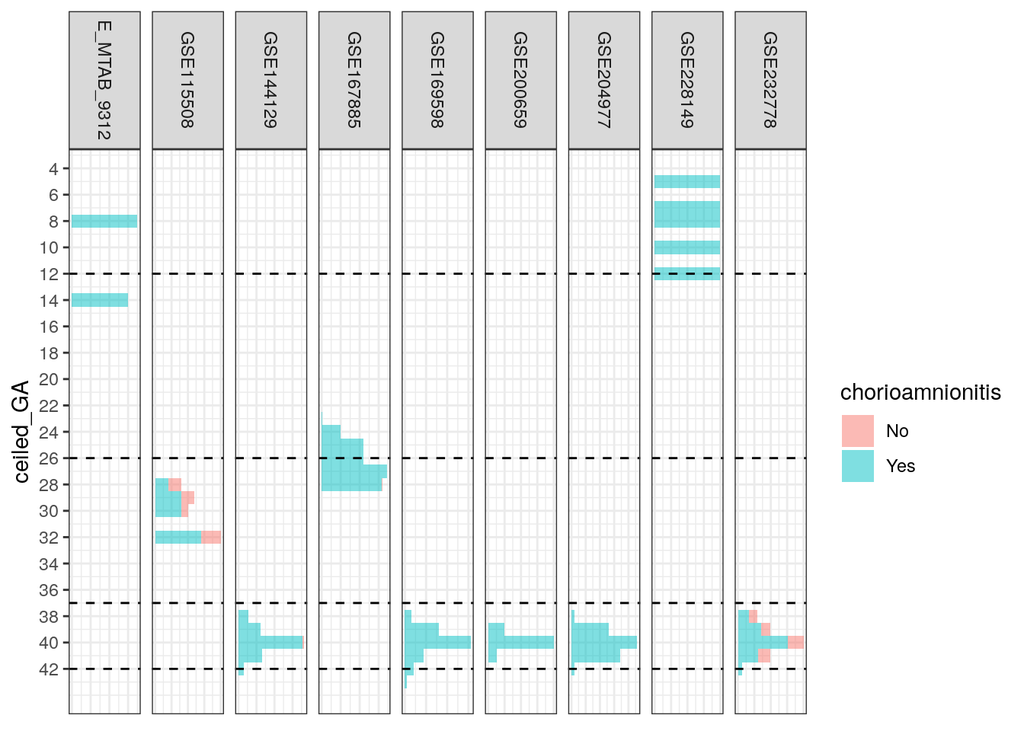

[figure not shown]

## Model development

### GA prediction

Normal-GA model was trained using samples without 12 of 13 available conditions. They were significantly correlated to GA: (1) fetal growth restriction (FGR); (2) PE; (3) PE onset (early/late/not applicable); (4) hemolysis, elevated liver enzyme, and low platelet (HELLP) syndrome; (5) anencephaly; (6) spina bifida; (7) diandric triploid; (8) miscarriage; (9) preterm delivery; (10) gestational diabetes mellitus (GDM); (11) large-for-gestational-age (LGA) infant; (12) subfertility; and (13) chorioamnionitis. We excluded preterm delivery because it was related to the outcome, i.e., GA, simply by definition.

### Preterm prediction

### GDM prediction

### LGA prediction

### Chorioamnionitis prediction

### GA res-full prediction

#### GA res-full random forest

### GA res-conds prediction

Res-Conds-GA model was similar to Resfull-GA model but we used predictors of multiplication values for each predicted probability and residual GA estimated by a model for the corresponding condition. Specifically, we trained a model using beta values of DMPs among samples with a condition. The rationale was that the conditions have different trajectories of when pregnancies are terminated and each pregnant woman has a different set of probabilities of the conditions. We used the predicted probabilities of the conditions from the prediction (Resfull-GA) model for the conditions.

### GA res-comb prediction

Res-Comb- model was considered because other conditions might affect pregnancy termination, not limited to the 12 conditions. In Res-Comb-GA model, we limited the degree of freedom of residual fitting using known phenotype information (Res-Conds-GA), thus, the second model only fitted the unexplained residual GA (Res-CPG-GA), simply to boost the prediction. Res-Comb-GA model consisted of three models for <37, ≥37 and ≤40, and >40 weeks’ gestation estimated by normal-GA model. The model numbers and periods were also determined according to clinical knowledge and pursuing normal distribution of residual GA. The estimated delivery date falls on 40 week’s gestation. Before this date, a pregnant woman might seek termination in advance due to a medical condition. Meanwhile, a normal pregnant woman might seek for termination since the delivery date. We used three approaches, i.e., predicting residual GA during: (1) <37 weeks’ gestation only (Res-Comb-PR-GA); (2) both <37 and ≥37 and ≤40 weeks’ gestation, i.e., term before the estimated delivery date (Res-Comb-PRTB-GA); and (3) all the three periods (Res-Comb-GA).

# Model evaluation

### Performance comparison

Table S9. Model evaluation

| model | metric | avg | lb | ub | current_best | win | sub | code | rank | task | val |
| --- | --- | --- | --- | --- | --- | --- | --- | --- | --- | --- | --- |
| Normal-GA | RMSE | 8.730 | 8.713 | 8.747 | 0.956 | No |  |  |  |  |  |
| Normal-GA | MAE | 7.765 | 7.746 | 7.784 | 0.721 | No |  |  |  |  |  |
| Normal-GA | r | 0.380 | 0.377 | 0.384 | 0.976 | No |  |  |  |  |  |
| Normal-GA (850k) | RMSE | 4.073 | 4.060 | 4.085 | 0.956 | No |  |  |  |  |  |
| Normal-GA (850k) | MAE | 3.032 | 3.021 | 3.042 | 0.721 | No |  |  |  |  |  |
| Normal-GA (850k) | r | 0.919 | 0.918 | 0.919 | 0.976 | No |  |  |  |  |  |
| Normal-GA (450k) | RMSE | 2.216 | 2.205 | 2.228 | 0.956 | No |  |  |  |  |  |
| Normal-GA (450k) | MAE | 1.425 | 1.417 | 1.433 | 0.721 | No |  |  |  |  |  |
| Normal-GA (450k) | r | 0.968 | 0.968 | 0.969 | 0.976 | No |  |  |  |  |  |
| Resfull-GA* | RMSE | 0.819 | 0.813 | 0.825 | 0.956 | Yes |  |  |  |  |  |
| Resfull-GA* | MAE | 0.572 | 0.570 | 0.574 | 0.721 | Yes |  |  |  |  |  |
| Resfull-GA* | r | 0.994 | 0.994 | 0.994 | 0.976 | Yes |  |  |  |  |  |
| Resfull-GA* (850k) | RMSE | 0.763 | 0.760 | 0.766 | 0.956 | Yes |  |  |  |  |  |
| Resfull-GA* (850k) | MAE | 0.551 | 0.549 | 0.553 | 0.721 | Yes |  |  |  |  |  |
| Resfull-GA* (850k) | r | 0.995 | 0.994 | 0.995 | 0.976 | Yes |  |  |  |  |  |
| Resfull-GA* (450k) | RMSE | 0.943 | 0.933 | 0.953 | 0.956 | Yes | 2 | isitthedarkhorse | 6 | 1 | 1.3552 |
| Resfull-GA* (450k) | MAE | 0.615 | 0.612 | 0.618 | 0.721 | Yes | 2 | isitthedarkhorse | 6 | 1 | 1.073 |
| Resfull-GA* (450k) | r | 0.992 | 0.991 | 0.992 | 0.976 | Yes | 2 | isitthedarkhorse | 6 | 1 | 0.9505 |
| Res-Conds-GA§ | RMSE | 2.027 | 2.019 | 2.034 | 0.956 | No |  |  |  |  |  |
| Res-Conds-GA§ | MAE | 1.551 | 1.546 | 1.556 | 0.721 | No |  |  |  |  |  |
| Res-Conds-GA§ | r | 0.961 | 0.960 | 0.961 | 0.976 | No |  |  |  |  |  |
| Res-Conds-GA§ (850k) | RMSE | 0.894 | 0.889 | 0.898 | 0.956 | Yes |  |  |  |  |  |
| Res-Conds-GA§ (850k) | MAE | 0.642 | 0.638 | 0.645 | 0.721 | Yes |  |  |  |  |  |
| Res-Conds-GA§ (850k) | r | 0.993 | 0.993 | 0.993 | 0.976 | Yes |  |  |  |  |  |
| Res-Conds-GA§ (450k) | RMSE | 0.768 | 0.764 | 0.772 | 0.956 | Yes | 7 | slidingdoors | 2 | 1 | 1.0949 |
| Res-Conds-GA§ (450k) | MAE | 0.539 | 0.536 | 0.541 | 0.721 | Yes | 7 | slidingdoors | 2 | 1 | 0.8843 |
| Res-Conds-GA§ (450k) | r | 0.995 | 0.995 | 0.995 | 0.976 | Yes | 7 | slidingdoors | 2 | 1 | 0.9642 |
| Res-Comb-GA | RMSE | 0.749 | 0.747 | 0.751 | 0.956 | Yes |  |  |  |  |  |
| Res-Comb-GA | MAE | 0.396 | 0.393 | 0.398 | 0.721 | Yes |  |  |  |  |  |
| Res-Comb-GA | r | 0.996 | 0.996 | 0.996 | 0.976 | Yes |  |  |  |  |  |
| Res-Comb-GA (850k) | RMSE | 0.702 | 0.698 | 0.706 | 0.956 | Yes |  |  |  |  |  |
| Res-Comb-GA (850k) | MAE | 0.505 | 0.503 | 0.507 | 0.721 | Yes |  |  |  |  |  |
| Res-Comb-GA (850k) | r | 0.995 | 0.995 | 0.996 | 0.976 | Yes |  |  |  |  |  |
| Res-Comb-GA (450k) | RMSE | 0.554 | 0.552 | 0.557 | 0.956 | Yes | 8 | pointofdivergence | 1 | 1 | 1.0772 |
| Res-Comb-GA (450k) | MAE | 0.387 | 0.385 | 0.388 | 0.721 | Yes | 8 | pointofdivergence | 1 | 1 | 0.8876 |
| Res-Comb-GA (450k) | r | 0.997 | 0.997 | 0.997 | 0.976 | Yes | 8 | pointofdivergence | 1 | 1 | 0.9663 |

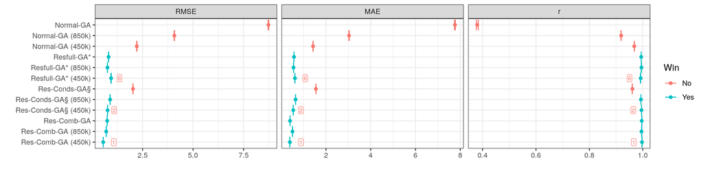

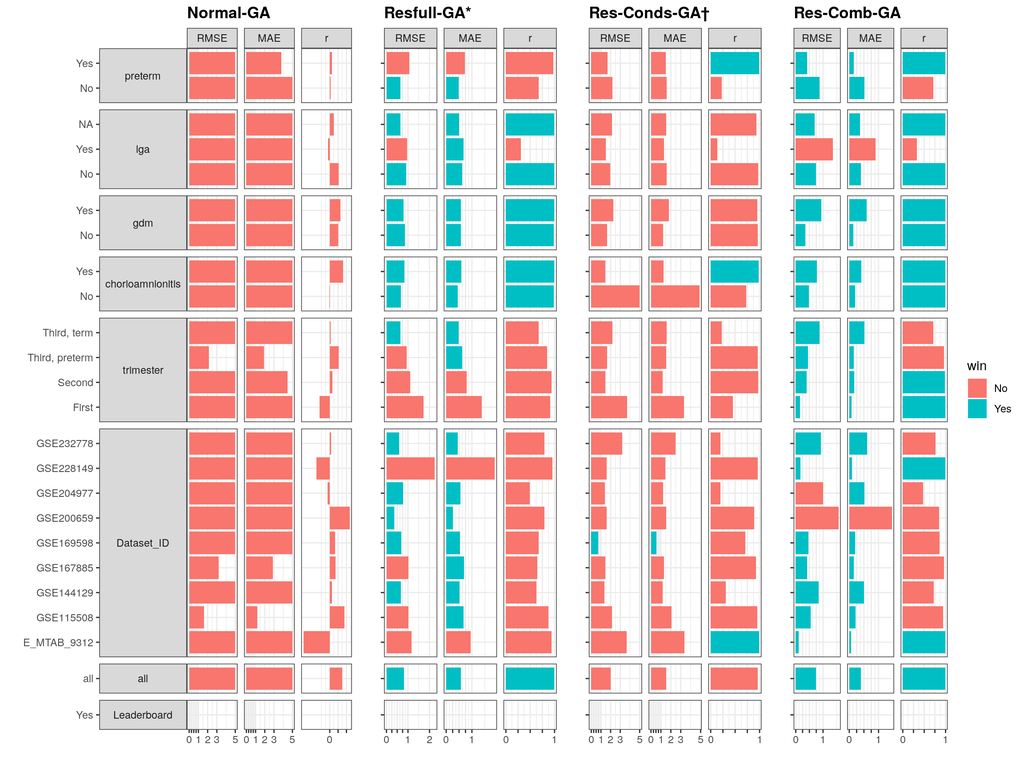

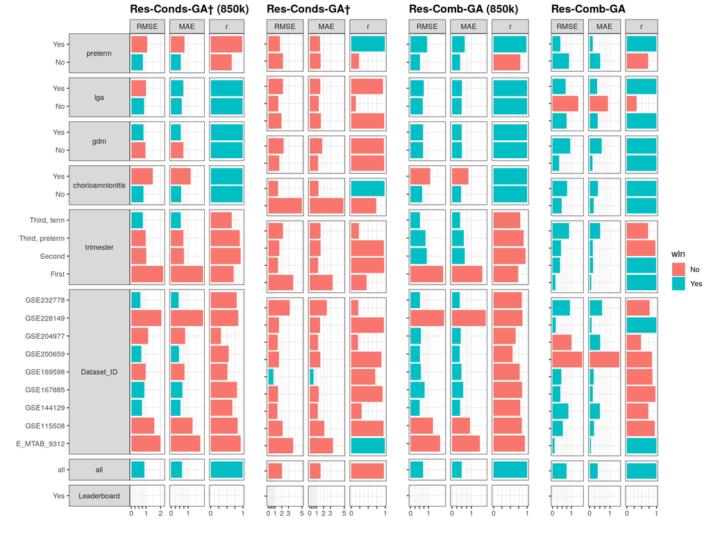

```
## $`Normal-GA`
```

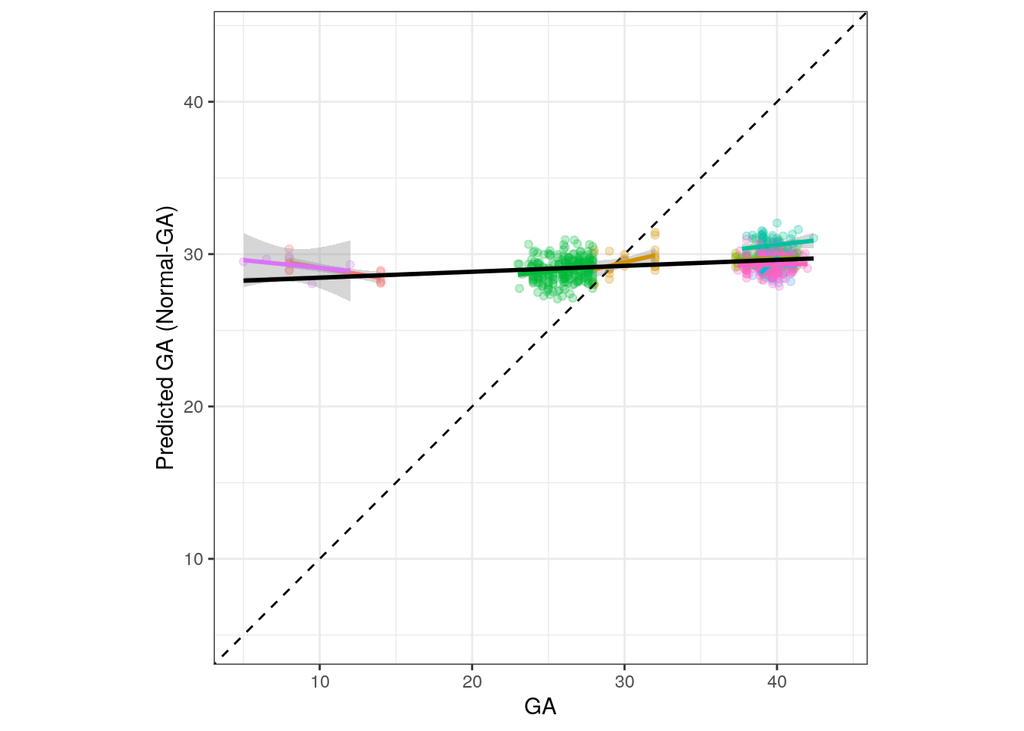

```
##
## $`Normal-GA (850k)`
```

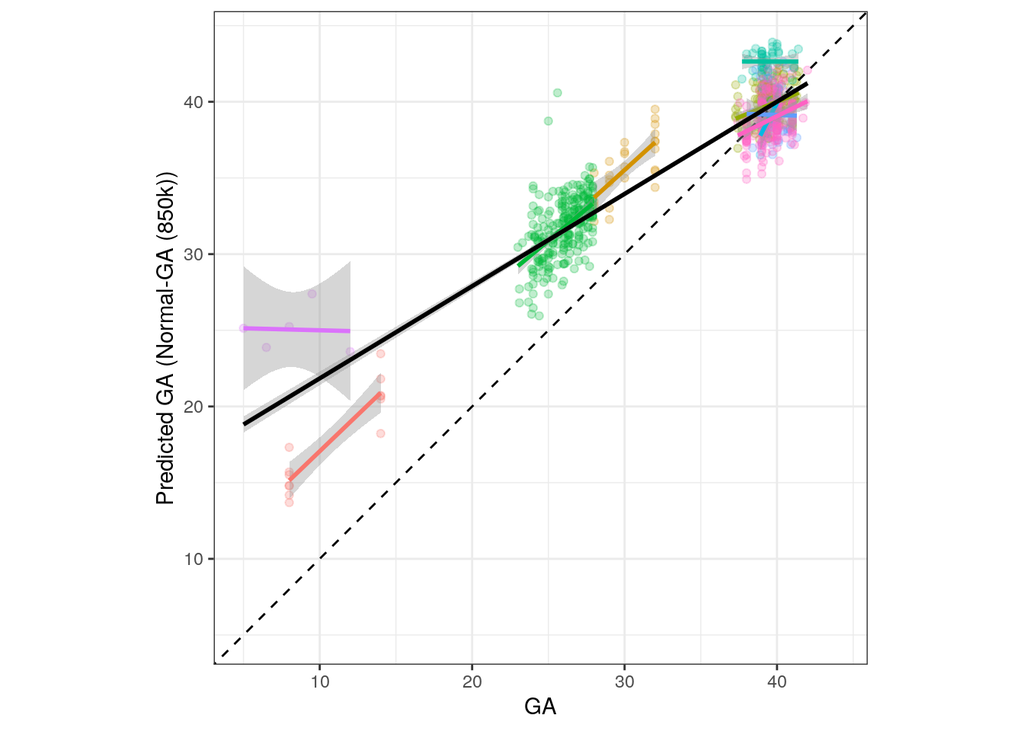

```
##
## $`Normal-GA (450k)`
```

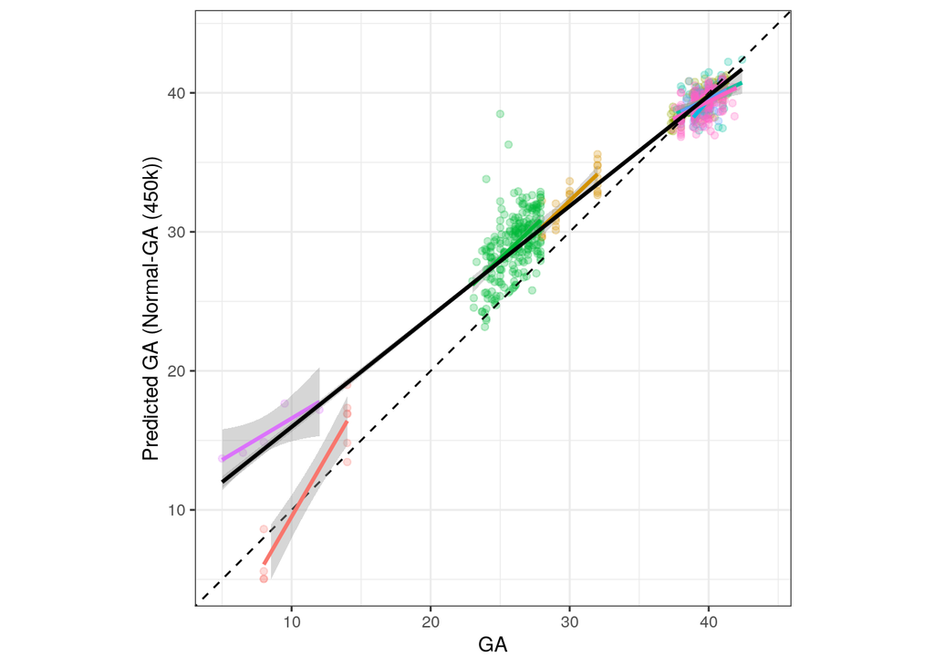

```
##
## $`Resfull-GA*`
```

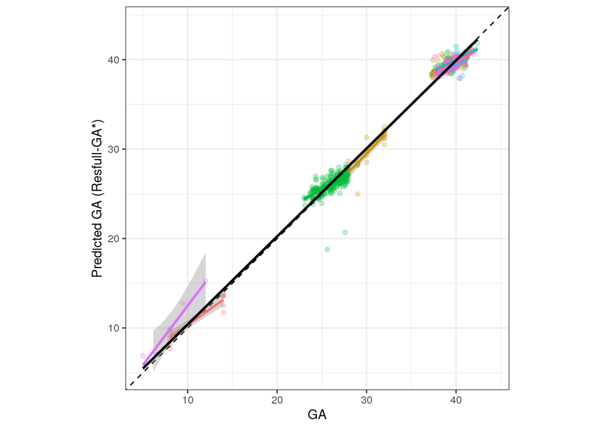

```
##
## $`Resfull-GA* (850k)`
```

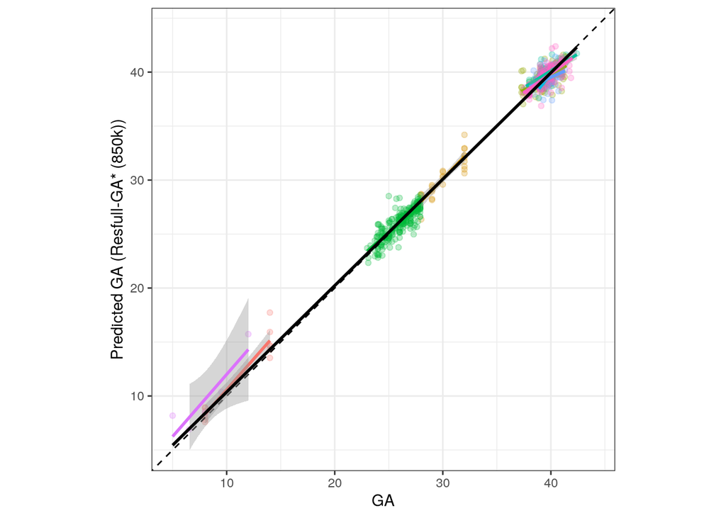

```
##
## $`Resfull-GA* (450k)`
```

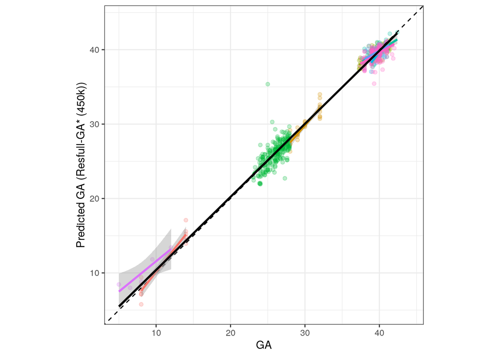

```
##
## $`Res-Conds-GA§`
```

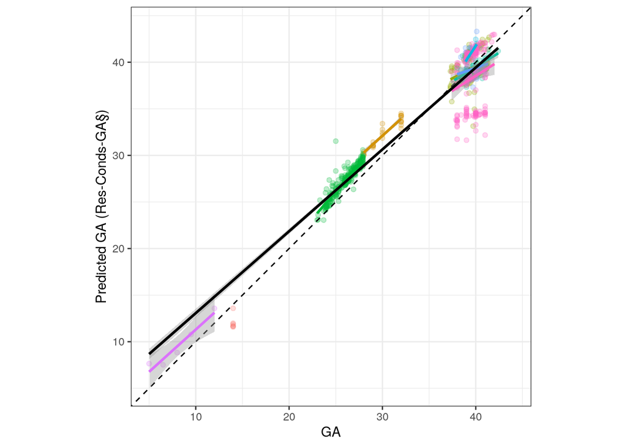

```
##
## $`Res-Conds-GA§ (850k)`
```

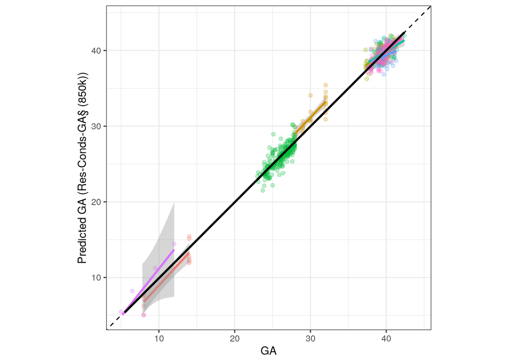

```
##
## $`Res-Conds-GA§ (450k)`
```

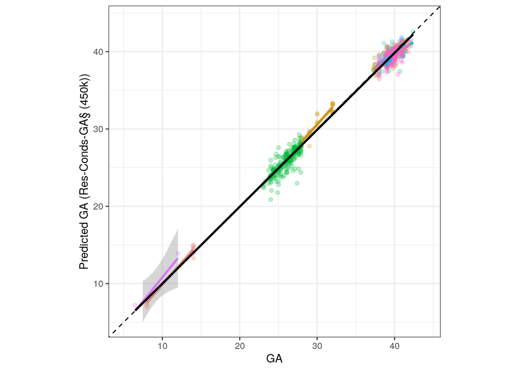

```
##
## $`Res-Comb-GA`
```

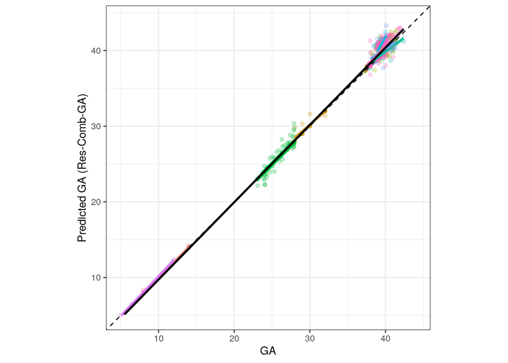

```
##
## $`Res-Comb-GA (850k)`
```

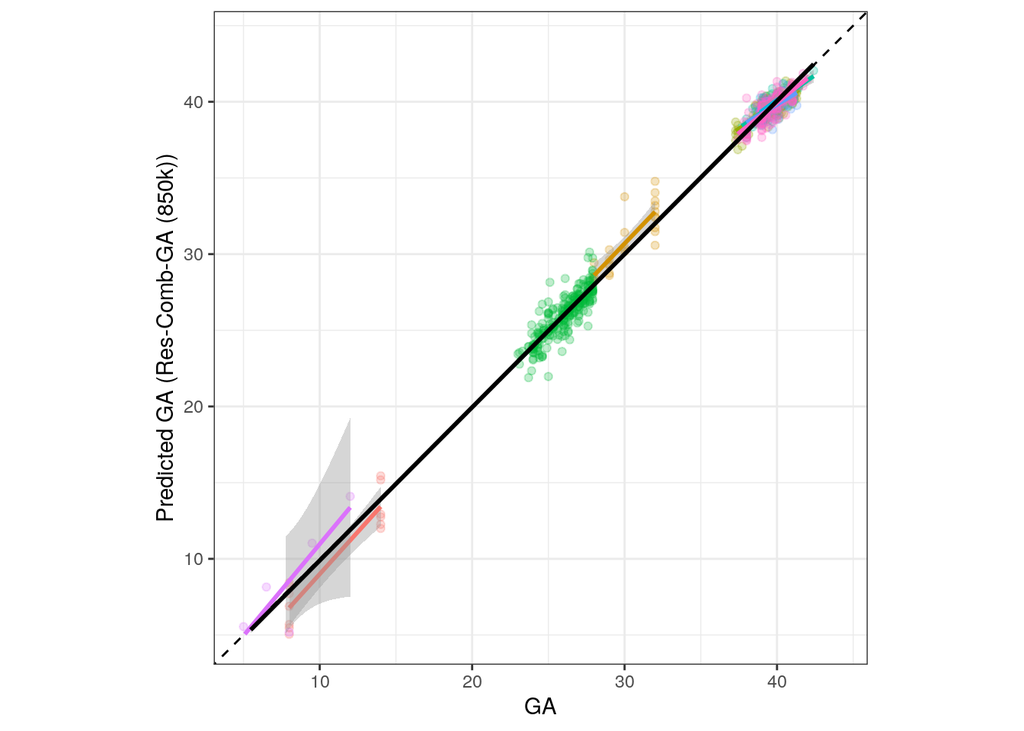

```
##
## $`Res-Comb-GA (450k)`
```

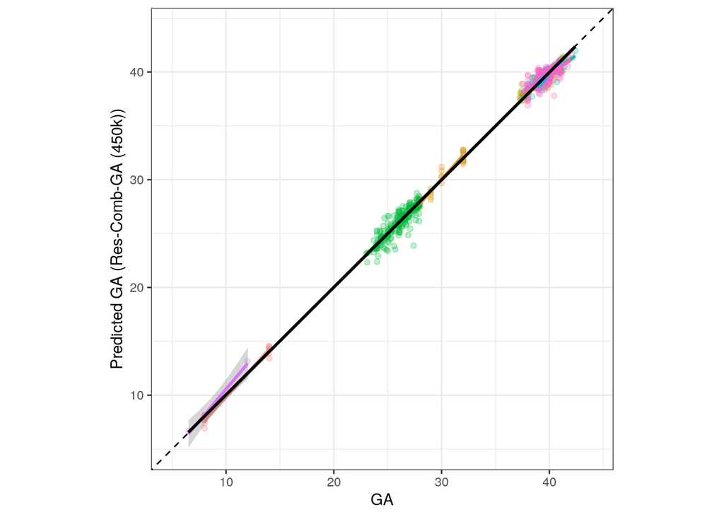

## Best model predictors

# Model submission

## Submission 1: GA res-comb-pred elastic net